# Relationship Between Preconception Iron Biomarkers and Pregnancy Loss

BMIN503/EPID600 Final Project

Author

Sarah Rothbard

## 1 Overview

For my final project, it is my goal to understand the relationship between pre-conception iron biomarkers and miscarriage risk. Specifically, I will be investigating this question among women with prior pregnancy loss, using data from the EAGeR (Effects of Aspirin in Gestation and Reproduction) trial.

Two faculty members I met with to discuss this project: Sunni Mumford, Professor & Deputy Director, Epidemiology Ellen Caniglia, Assistant Professor, Epidemiology

Sunni Mumford has worked with EAGeR data before and informed me about the EAGeR data structure and best practices for the analyses. We discussed the feasibility of my research question; data is available within EAGeR on both iron biomarkers and miscarriage. Iron biomarker data is from baseline (preconception) and pregnancy loss data is collected during follow-up with the time metric being gestational weeks until miscarriage or birth. Ellen Caniglia encouraged me to perform a literature review to determine which iron biomarker may be best to use and after discussion, we decided on serum ferritin. With both Dr. Mumford and Dr. Caniglia, I discussed potential confounders based on the literature.

[srothbard](https://github.com/srothbard/BMIN503_Final_Project)

## 2 Introduction

Miscarriage, defined as the spontaneous loss of a pregnancy before 20 weeks of gestation, is a common and emotionally devastating outcome, affecting approximately 10–20% of recognized pregnancies. Despite its prevalence, the underlying causes of miscarriage are not fully understood, particularly among women with a history of pregnancy loss. Iron, an essential micronutrient involved in oxygen transport, hormone synthesis, and cellular function, plays a critical role in reproductive health. Iron deficiency—even in the absence of anemia—has been associated with impaired implantation, placental development, and increased miscarriage risk. Serum ferritin, a biomarker of iron stores, is particularly relevant in assessing iron status in women of reproductive age. This final project aims to investigate whether preconception serum ferritin levels are associated with miscarriage risk among women with prior pregnancy loss, using data from the EAGeR (Effects of Aspirin in Gestation and Reproduction) trial. This research is inherently interdisciplinary, integrating perspectives from epidemiology, reproductive biology, nutrition science, and biostatistics. Epidemiological methods are essential for analyzing longitudinal data and identifying confounding factors, while reproductive biology provides insight into how iron status may influence implantation and early gestational development. Nutrition science contributes to understanding iron metabolism and its biomarkers, and biostatistics enables rigorous modeling of time-to-event outcomes. The EAGeR trial provides a unique opportunity to explore the relationship between serum ferritin and miscarriage, as it includes detailed data on preconception serum ferritin levels and prospective tracking of pregnancy outcomes by gestational week. Identifying relevant confounders such as age, BMI, and parity is essential for isolating the true effect of iron status, and integrating insights from epidemiology, nutrition science, and reproductive biology is critical to fully understanding this complex relationship.

## 3 Methods

**Study Population** This study utilizes data from the Effects of Aspirin in Gestation and Reproduction (EAGeR) trial, a multi-site randomized controlled trial designed to evaluate the impact of low-dose aspirin on reproductive outcomes. The analytic sample includes 1,228 women aged 18–40 years who had experienced one or two prior pregnancy losses and were actively attempting to conceive. Participants were followed until miscarriage or birth occurred, with pregnancy outcomes tracked in gestational weeks.

**Exposure Assessment** The primary exposure of interest is iron status, measured via serum ferritin concentrations at baseline (preconception). Serum ferritin was assessed using standardized immunoassays, with quality control procedures including re-testing of samples to ensure reliability. Serum ferritin is selected as the primary biomarker due to its clinical relevance and widespread use in assessing iron stores. Iron deficiency is commonly defined as serum ferritin <15 µg/L by the World Health Organization (WHO), but recent literature suggests a cutoff of <30 µg/L may improve sensitivity and specificity in both healthy and clinical populations. Ferritin levels are dichotomized at the <30 µg/L threshold for analysis.

**Outcome Measurement** The primary outcome is miscarriage, defined as a chemical or clinical loss of pregnancy (before 20 weeks of gestation).

**Covariates** Potential confounders were identified through literature review and include: age, Body Mass Index (BMI), race/ethnicity, parity, household income, use of prenatal vitamins, physical activity, smoking status, and aspirin treatment assignment. These covariates are of interest because they may influence both iron status and miscarriage risk. Age is a well-established risk factor for miscarriage and may also affect iron stores. BMI can alter ferritin levels through inflammation and is linked to adverse reproductive outcomes. Race/ethnicity captures biological and social differences that influence diet, iron metabolism, and pregnancy outcomes. Parity reflects prior reproductive history, which can deplete iron stores and affect miscarriage risk. Household income serves as a proxy for socioeconomic status, influencing diet quality and access to care. Prenatal vitamin use is relevant because supplements often contain iron, potentially modifying ferritin levels. Physical activity may impact inflammation and iron metabolism, while extreme activity has been associated with miscarriage. Smoking is included due to its known association with adverse pregnancy outcomes and potential effects on nutrient absorption. Finally, aspirin treatment assignment is controlled for as part of the EAGeR trial design, given its possible influence on implantation and miscarriage risk.

**Statistical Analysis** Descriptive statistics summarize the distribution of serum ferritin and covariates. Two versions of Table 1 present baseline characteristics stratified by serum ferritin status (<30 µg/L vs. ≥30 µg/L; <15 µg/L vs. ≥15 µg/L). Risk ratios are estimated using a Poisson regression model with a log link and robust standard errors, implemented via the survey package (svyglm) in R. This model is chosen because it provides a reliable way to estimate risk ratios directly for binary outcomes, avoiding convergence issues common in log-binomial models. Initial models are unadjusted, followed by adjusted models incorporating identified covariates. Inverse probability weights were applied to account for selection into pregnancy. Sensitivity analyses explore the use of the WHO ferritin cutoff as an alternative metric for iron deficiency and stratifying by potential effect modifiers.

```r
R_LIBS_USER="C:/Users/sarahrot/AppData/Local/R/win-library/4.5"
#load packages
library(labelled)
library(haven)
library(dplyr)
#Read in SAS dataset
merged_all <- read_sas("C:\\Users\\sarahrot\\Box\\Sarah - EAGeR data\\merged_all.sas7bdat")

#create a new data frame with transformations
pretbl1 <- merged_all %>%
  dplyr::mutate(
    # Categories for serum ferritin
    ferritin30cat = dplyr::case_when(
      !is.na(ferritin) & ferritin < 30 ~ 1,
      ferritin >= 30 ~ 2
    ),
    ferritin15cat = dplyr::case_when(
      !is.na(ferritin) & ferritin < 15 ~ 1,
      ferritin >= 15 ~ 2
    ),

    # Age categories
    agecat = dplyr::case_when(
      age > 18 & age < 23 ~ 1,
      age >= 23 & age < 28 ~ 2,
      age >= 28 & age < 33 ~ 3,
      age >= 33 & age < 38 ~ 4,
      age >= 38 ~ 5
    ),

    # BMI categories
    bmicat = dplyr::case_when(
      is.na(BMI) ~ NA_real_,
      BMI < 25 ~ 1,
      BMI >= 25 & BMI <= 30 ~ 2,
      BMI > 30 ~ 3
    ),

    # Parity categories
    parity = dplyr::case_when(
      Preg_no_loss == 0 ~ 0,
      Preg_no_loss %in% c(1, 2, 3) ~ 1
    ),

    # Income categories
    income = dplyr::case_when(
      DMGv34 %in% c(1, 2) ~ 1,
      DMGv34 %in% c(3, 4) ~ 2,
      DMGv34 == 5 ~ 3
    ),

# Smoking categories
smoking = dplyr::case_when(
  smoke %in% c("Dialy", "Fewer") ~ 1,
  smoke == "Never" ~ 0,
  TRUE ~ NA_real_
    )
  )


#Labeling values of variables based on data dictionary
pretbl1$bmicat <- factor(pretbl1$bmicat,
                         levels = c(1, 2, 3),
                         labels = c("1: <25", "2: 25–30", "3: >30"))
pretbl1$income <- factor(pretbl1$income,
                         levels = c(1, 2, 3),
                         labels = c("1: <$40,000", "2: $40,000–$99,999", "3: ≥$100,000"))
pretbl1$white <- factor(pretbl1$white, levels = c(0, 1), labels = c("Non-white", "White"))
pretbl1$is_treatment <- factor(pretbl1$is_treatment, levels = c(0, 1), labels = c("Control", "Treatment"))
pretbl1$ferritin30cat <- factor(pretbl1$ferritin30cat,
                                levels = c(1, 2),
                                labels = c("1: <30 microgram/L", "2: ≥30 microgram/L"))
pretbl1$ferritin15cat <- factor(pretbl1$ferritin15cat,
                                levels = c(1, 2),
                                labels = c("1: <15 microgram/L", "2: ≥15 microgram/L"))
pretbl1$Exercise <- factor(pretbl1$Exercise,
                           levels = c(1, 2, 3),
                           labels = c("1: Low", "2: Moderate", "3: High"))
pretbl1$parity <- factor(pretbl1$parity,
                         levels = c(0, 1),
                         labels = c("0: Nulliparous", "1: Parous"))
pretbl1$take_vitamins[pretbl1$take_vitamins == ""] <- NA

pretbl1$smoking <- factor(pretbl1$smoking,
                          levels = c(0, 1),
                          labels = c("Never", "Ever"))

#labeling variables themselves
var_label(pretbl1$age) <- "Age (years)"
var_label(pretbl1$bmicat) <- "BMI category"
var_label(pretbl1$income) <- "Income category"
var_label(pretbl1$parity) <- "Parity"
var_label(pretbl1$white) <- "Race"
var_label(pretbl1$take_vitamins) <- "Prenatal Vitamin Use"
var_label(pretbl1$Exercise) <- "Exercise level"
var_label(pretbl1$is_treatment) <- "Treatment assignment"
var_label(pretbl1$ferritin30cat) <- "Serum ferritin (<30 µg/L cutoff)"
var_label(pretbl1$ferritin15cat) <- "Serum ferritin (<15 µg/L cutoff)"
var_label(pretbl1$smoking) <- "Smoking status"
```

## 4 Results

```r
#load packages for creating Table 1

library(gtsummary)
library(tableone)

#Table 1 (by 30 microgram/L ferritin cutoff)
tbl1_30 <- pretbl1 %>%
  select(ferritin30cat, age, bmicat, white, parity, income, take_vitamins, Exercise, is_treatment, smoking) %>%
  tbl_summary(by = ferritin30cat, missing = "no") %>%
  add_p() %>%
  bold_labels()
```

```
246 missing rows in the "ferritin30cat" column have been removed.
```

```r
#Table 1 (by 15 microgram/L ferritin cutoff)
tbl1_15 <- pretbl1 %>%
  select(ferritin15cat, age, bmicat, white, parity, income, take_vitamins, Exercise, is_treatment, smoking) %>%
  tbl_summary(by = ferritin15cat, missing = "no") %>%
  add_p() %>%
  bold_labels()
```

```
246 missing rows in the "ferritin15cat" column have been removed.
```

```r
tbl1_30
```

| **Characteristic** | **1: <30 microgram/L** N = 294<sup>1</sup> | **2: ≥30 microgram/L** N = 688<sup>1</sup> | **p-value**<sup>2</sup> |
| --- | --- | --- | --- |
| Age (years) | 28.0 (24.8, 31.5) | 28.5 (25.5, 31.9) | 0.13 |
| BMI category |  |  | 0.9 |
| 1: <25 | 150 (52%) | 364 (54%) |  |
| 2: 25–30 | 72 (25%) | 159 (23%) |  |
| 3: >30 | 65 (23%) | 157 (23%) |  |
| Race |  |  | 0.2 |
| Non-white | 21 (7.1%) | 34 (4.9%) |  |
| White | 273 (93%) | 654 (95%) |  |
| Parity |  |  | 0.013 |
| 0: Nulliparous | 104 (35%) | 302 (44%) |  |
| 1: Parous | 190 (65%) | 386 (56%) |  |
| Income category |  |  | 0.011 |
| 1: <$40,000 | 112 (38%) | 200 (29%) |  |
| 2: $40,000–$99,999 | 66 (23%) | 200 (29%) |  |
| 3: ≥$100,000 | 115 (39%) | 288 (42%) |  |
| Prenatal Vitamin Use |  |  | 0.7 |
| No folic - no vitamins | 20 (6.9%) | 50 (7.4%) |  |
| No folic - take vitamins | 29 (10%) | 79 (12%) |  |
| YES | 241 (83%) | 549 (81%) |  |
| Exercise level |  |  | 0.3 |
| 1: Low | 90 (31%) | 187 (27%) |  |
| 2: Moderate | 128 (44%) | 291 (42%) |  |
| 3: High | 76 (26%) | 210 (31%) |  |
| Treatment assignment |  |  | 0.9 |
| Control | 144 (49%) | 341 (50%) |  |
| Treatment | 150 (51%) | 347 (50%) |  |
| Smoking status |  |  | 0.3 |
| Never | 259 (89%) | 588 (86%) |  |
| Ever | 33 (11%) | 92 (14%) |  |

<sup>1</sup> Median (Q1, Q3); n (%)  
<sup>2</sup> Wilcoxon rank sum test; Pearson’s Chi-squared test

```r
tbl1_15
```

| **Characteristic** | **1: <15 microgram/L** N = 91<sup>1</sup> | **2: ≥15 microgram/L** N = 891<sup>1</sup> | **p-value**<sup>2</sup> |
| --- | --- | --- | --- |
| Age (years) | 27.6 (25.0, 31.5) | 28.5 (25.3, 31.9) | 0.4 |
| BMI category |  |  | 0.008 |
| 1: <25 | 35 (39%) | 479 (55%) |  |
| 2: 25–30 | 32 (36%) | 199 (23%) |  |
| 3: >30 | 23 (26%) | 199 (23%) |  |
| Race |  |  | 0.005 |
| Non-white | 11 (12%) | 44 (4.9%) |  |
| White | 80 (88%) | 847 (95%) |  |
| Parity |  |  | 0.009 |
| 0: Nulliparous | 26 (29%) | 380 (43%) |  |
| 1: Parous | 65 (71%) | 511 (57%) |  |
| Income category |  |  | 0.023 |
| 1: <$40,000 | 40 (44%) | 272 (31%) |  |
| 2: $40,000–$99,999 | 18 (20%) | 248 (28%) |  |
| 3: ≥$100,000 | 32 (36%) | 371 (42%) |  |
| Prenatal Vitamin Use |  |  | 0.3 |
| No folic - no vitamins | 10 (11%) | 60 (6.8%) |  |
| No folic - take vitamins | 10 (11%) | 98 (11%) |  |
| YES | 69 (78%) | 721 (82%) |  |
| Exercise level |  |  | 0.039 |
| 1: Low | 36 (40%) | 241 (27%) |  |
| 2: Moderate | 34 (37%) | 385 (43%) |  |
| 3: High | 21 (23%) | 265 (30%) |  |
| Treatment assignment |  |  | 0.5 |
| Control | 42 (46%) | 443 (50%) |  |
| Treatment | 49 (54%) | 448 (50%) |  |
| Smoking status |  |  | 0.9 |
| Never | 78 (87%) | 769 (87%) |  |
| Ever | 12 (13%) | 113 (13%) |  |

<sup>1</sup> Median (Q1, Q3); n (%)  
<sup>2</sup> Wilcoxon rank sum test; Pearson’s Chi-squared test

```r
#Saving table 1 versions as documents
as_gt(tbl1_30) %>%
  gt::gtsave("Table1_30ferr.docx")

as_gt(tbl1_15) %>%
  gt::gtsave("Table1_15ferr.docx")
```

Among 1,228 participants, 982 had valid serum ferritin levels measured; serum ferritin levels varied across categories. Using the 30 µg/L cutoff, 294 women (29.9%) had ferritin <30 µg/L and 688 (70.1%) had ferritin ≥30 µg/L. Women with ferritin <30 µg/L were more likely to be parous (65% vs. 56%, p=0.013). Income also differed significantly (p=0.011), with a higher proportion of women in the <30 µg/L group reporting income <$40,000 (38% vs. 29%). Other characteristics, including age, BMI, race, prenatal vitamin use, exercise level, aspirin treatment assignment, and smoking status were similar across ferritin categories.

Using the 15 µg/L cutoff, 91 women (9.3%) had ferritin <15 µg/L and 891 (90.7%) had ferritin ≥15 µg/L. Women with ferritin <15 µg/L were more likely to have higher BMI (p=0.008), be parous (71% vs. 57%, p=0.009), and report lower income (p=0.023). Race also differed significantly (p=0.005), with non-White participants more common in the <15 µg/L group (12% vs. 4.9%). Exercise level varied by ferritin status (p=0.039), with low activity more frequent among women with ferritin <15 µg/L (40% vs. 27%). Age, prenatal vitamin use, treatment assignment, and smoking status did not differ significantly between groups.

```r
# Fit logistic model for pregnancy
selection_model <- glm(pptnew ~ ferritin30cat + age + bmicat + white + parity + income + smoking + take_vitamins + Exercise + is_treatment,
                       data = pretbl1,
                       family = binomial)

# Compute predicted probabilities and IP weights
pretbl1 <- pretbl1 %>%
  mutate(pred_preg = predict(selection_model, newdata = pretbl1, type = "response"),
         ipw = ifelse(pptnew == 1, 1 / pred_preg, 1 / (1 - pred_preg)))

# Filter dataset for those who got pregnant
# and set level 2 as reference for ferritin30cat
subset_data <- pretbl1 %>%
  filter(pptnew == 1) %>%
  mutate(ferritin30cat = relevel(ferritin30cat, ref = "2: ≥30 microgram/L"))

subset_data <- subset_data %>% filter(!is.na(ipw))

#Cases in each group
subset_data %>%
  group_by(ferritin30cat) %>%
  summarise(
    n_anyloss = sum(anyloss == 1, na.rm = TRUE),
    total = n(),
    percent = round(100 * n_anyloss / total, 1)
  )
```

```
# A tibble: 2 × 4
  ferritin30cat      n_anyloss total percent
  <fct>                  <int> <int>   <dbl>
1 2: ≥30 microgram/L       125   456    27.4
2 1: <30 microgram/L        32   181    17.7
```

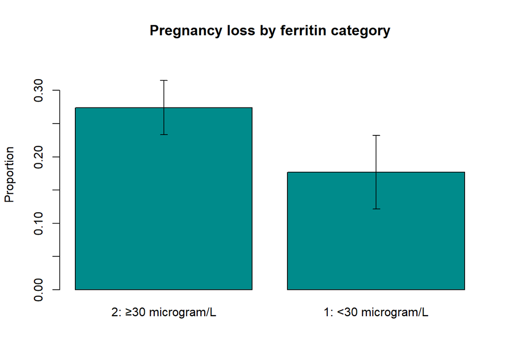

```r
#Plotting pregnancy loss risk by s-ferritin category
tab <- with(subset_data, tapply(anyloss == 1, ferritin30cat, function(x) mean(x, na.rm = TRUE)))
n <- with(subset_data, tapply(anyloss, ferritin30cat, function(x) length(x)))
se <- sqrt(tab * (1 - tab) / n)
lcl <- pmax(0, tab - 1.96 * se); ucl <- pmin(1, tab + 1.96 * se)
bp <- barplot(tab, ylim = c(0, max(ucl)*1.1),
              main = "Pregnancy loss by ferritin category",
              ylab = "Proportion", col = "darkcyan")
arrows(bp, lcl, bp, ucl, angle = 90, code = 3, length = 0.05)
```

```r
# Unadjusted model using survey design
library(survey)
library(broom)

design <- svydesign(ids = ~1, weights = ~ipw, data = subset_data)

unadj_model <- svyglm(anyloss ~ ferritin30cat,
                      design = design,  # same design object with weights
                      family = quasipoisson(link = "log"))

summary(unadj_model)
```

```
Call:
svyglm(formula = anyloss ~ ferritin30cat, design = design, family = quasipoisson(link = "log"))

Survey design:
svydesign(ids = ~1, weights = ~ipw, data = subset_data)

Coefficients:
                                Estimate Std. Error t value Pr(>|t|)
(Intercept)                     -1.26557    0.07691 -16.456   <2e-16 ***
ferritin30cat1: <30 microgram/L -0.41959    0.17947  -2.338   0.0197 *
---
Signif. codes:  0 '***' 0.001 '**' 0.01 '*' 0.05 '.' 0.1 ' ' 1

(Dispersion parameter for quasipoisson family taken to be 0.7477249)

Number of Fisher Scoring iterations: 5
```

```r
exp(cbind(RR = coef(unadj_model), confint(unadj_model)))
```

```
                                       RR     2.5 %    97.5 %
(Intercept)                     0.2820795 0.2425405 0.3280641
ferritin30cat1: <30 microgram/L 0.6573184 0.4620864 0.9350362
```

```r
#adjusted model

adjmodel <- svyglm(anyloss ~ ferritin30cat + age + bmicat + white + parity +
                     income + smoking + take_vitamins + Exercise + is_treatment,
                   design = design,
                   family = quasipoisson(link = "log"))

summary(adjmodel)
```

```
Call:
svyglm(formula = anyloss ~ ferritin30cat + age + bmicat + white +
    parity + income + smoking + take_vitamins + Exercise + is_treatment,
    design = design, family = quasipoisson(link = "log"))

Survey design:
svydesign(ids = ~1, weights = ~ipw, data = subset_data)

Coefficients:
                                       Estimate Std. Error t value Pr(>|t|)
(Intercept)                           -2.017172   0.641301  -3.145  0.00174 **
ferritin30cat1: <30 microgram/L       -0.351866   0.180107  -1.954  0.05119 .
age                                    0.037993   0.016619   2.286  0.02258 *
bmicat2: 25–30                        -0.033213   0.179856  -0.185  0.85355
bmicat3: >30                           0.251645   0.167980   1.498  0.13462
whiteWhite                            -0.206883   0.333753  -0.620  0.53557
parity1: Parous                       -0.374443   0.141476  -2.647  0.00833 **
income2: $40,000–$99,999              -0.211105   0.206555  -1.022  0.30716
income3: ≥$100,000                    -0.006878   0.175561  -0.039  0.96876
smokingEver                            0.361879   0.181967   1.989  0.04717 *
take_vitaminsNo folic - take vitamins  0.246458   0.334781   0.736  0.46190
take_vitaminsYES                       0.018387   0.302520   0.061  0.95155
Exercise2: Moderate                   -0.010415   0.175938  -0.059  0.95282
Exercise3: High                        0.016081   0.187343   0.086  0.93162
is_treatmentTreatment                 -0.125306   0.139916  -0.896  0.37082
---
Signif. codes:  0 '***' 0.001 '**' 0.01 '*' 0.05 '.' 0.1 ' ' 1

(Dispersion parameter for quasipoisson family taken to be 0.7398045)

Number of Fisher Scoring iterations: 5
```

```r
exp(cbind(RR = coef(adjmodel), confint(adjmodel)))
```

```
                                             RR      2.5 %    97.5 %
(Intercept)                           0.1330312 0.03775835 0.4686988
ferritin30cat1: <30 microgram/L       0.7033745 0.49383313 1.0018276
age                                   1.0387240 1.00537155 1.0731829
bmicat2: 25–30                        0.9673330 0.67949060 1.3771097
bmicat3: >30                          1.2861388 0.92475032 1.7887564
whiteWhite                            0.8131151 0.42218954 1.5660173
parity1: Parous                       0.6876719 0.52086056 0.9079064
income2: $40,000–$99,999              0.8096890 0.53970436 1.2147323
income3: ≥$100,000                    0.9931454 0.70353172 1.4019805
smokingEver                           1.4360257 1.00454518 2.0528392
take_vitaminsNo folic - take vitamins 1.2794854 0.66300034 2.4692035
take_vitaminsYES                      1.0185571 0.56231298 1.8449844
Exercise2: Moderate                   0.9896395 0.70052943 1.3980659
Exercise3: High                       1.0162110 0.70340675 1.4681191
is_treatmentTreatment                 0.8822270 0.67027313 1.1612049
```

```r
#Sensitivity analyses

# Fit logistic model for pregnancy (different ferritin cutoff)
selection_model2 <- glm(pptnew ~ ferritin15cat + age + bmicat + white + parity + income + smoking + take_vitamins + Exercise + is_treatment,
                       data = pretbl1,
                       family = binomial)

# Compute predicted probabilities and IP weights
senset <- pretbl1 %>%
  mutate(pred_preg = predict(selection_model2, newdata = pretbl1, type = "response"),
         ipw = ifelse(pptnew == 1, 1 / pred_preg, 1 / (1 - pred_preg)))

# Filter dataset for those who got pregnant
# and set level 2 as reference for ferritin15cat
subset_data2 <- senset %>%
  filter(pptnew == 1) %>%
  mutate(ferritin15cat = relevel(ferritin15cat, ref = "2: ≥15 microgram/L"))

subset_data2 <- subset_data2 %>% filter(!is.na(ipw))

#Cases in each group
subset_data2 %>%
  group_by(ferritin15cat) %>%
  summarise(
    n_anyloss = sum(anyloss == 1, na.rm = TRUE),
    total = n(),
    percent = round(100 * n_anyloss / total, 1)
  )
```

```
# A tibble: 2 × 4
  ferritin15cat      n_anyloss total percent
  <fct>                  <int> <int>   <dbl>
1 2: ≥15 microgram/L       148   585    25.3
2 1: <15 microgram/L         9    52    17.3
```

```r
# Unadjusted model using survey design
design2 <- svydesign(ids = ~1, weights = ~ipw, data = subset_data2)

unadj_model2 <- svyglm(anyloss ~ ferritin15cat,
                      design = design2,  # same design object with weights
                      family = quasipoisson(link = "log"))

summary(unadj_model2)
```

```
Call:
svyglm(formula = anyloss ~ ferritin15cat, design = design2, family = quasipoisson(link = "log"))

Survey design:
svydesign(ids = ~1, weights = ~ipw, data = subset_data2)

Coefficients:
                                Estimate Std. Error t value Pr(>|t|)
(Intercept)                      -1.3386     0.0716 -18.694   <2e-16 ***
ferritin15cat1: <15 microgram/L  -0.4552     0.3190  -1.427    0.154
---
Signif. codes:  0 '***' 0.001 '**' 0.01 '*' 0.05 '.' 0.1 ' ' 1

(Dispersion parameter for quasipoisson family taken to be 0.7474928)

Number of Fisher Scoring iterations: 5
```

```r
exp(cbind(RR = coef(unadj_model2), confint(unadj_model2)))
```

```
                                       RR     2.5 %   97.5 %
(Intercept)                     0.2622218 0.2278264 0.301810
ferritin15cat1: <15 microgram/L 0.6343188 0.3390141 1.186854
```

```r
#adjusted model

adjmodel2 <- svyglm(anyloss ~ ferritin15cat + age + bmicat + white + parity +
                     income + smoking + take_vitamins + Exercise + is_treatment,
                   design = design2,
                   family = quasipoisson(link = "log"))

summary(adjmodel2)
```

```
Call:
svyglm(formula = anyloss ~ ferritin15cat + age + bmicat + white +
    parity + income + smoking + take_vitamins + Exercise + is_treatment,
    design = design2, family = quasipoisson(link = "log"))

Survey design:
svydesign(ids = ~1, weights = ~ipw, data = subset_data2)

Coefficients:
                                       Estimate Std. Error t value Pr(>|t|)
(Intercept)                           -2.128133   0.631312  -3.371 0.000795 ***
ferritin15cat1: <15 microgram/L       -0.346333   0.330170  -1.049 0.294607
age                                    0.039271   0.016669   2.356 0.018784 *
bmicat2: 25–30                        -0.026096   0.178784  -0.146 0.883997
bmicat3: >30                           0.267829   0.167133   1.602 0.109556
whiteWhite                            -0.189141   0.334161  -0.566 0.571586
parity1: Parous                       -0.381355   0.140492  -2.714 0.006823 **
income2: $40,000–$99,999              -0.171494   0.206677  -0.830 0.406988
income3: ≥$100,000                     0.019089   0.177219   0.108 0.914255
smokingEver                            0.363932   0.180532   2.016 0.044242 *
take_vitaminsNo folic - take vitamins  0.237574   0.335019   0.709 0.478506
take_vitaminsYES                      -0.008875   0.301541  -0.029 0.976529
Exercise2: Moderate                   -0.018974   0.175098  -0.108 0.913744
Exercise3: High                        0.020546   0.186897   0.110 0.912497
is_treatmentTreatment                 -0.134357   0.139640  -0.962 0.336340
---
Signif. codes:  0 '***' 0.001 '**' 0.01 '*' 0.05 '.' 0.1 ' ' 1

(Dispersion parameter for quasipoisson family taken to be 0.7446131)

Number of Fisher Scoring iterations: 5
```

```r
exp(cbind(RR = coef(adjmodel2), confint(adjmodel2)))
```

```
                                             RR      2.5 %    97.5 %
(Intercept)                           0.1190593 0.03446212 0.4113249
ferritin15cat1: <15 microgram/L       0.7072766 0.36982798 1.3526293
age                                   1.0400525 1.00655872 1.0746608
bmicat2: 25–30                        0.9742416 0.68578660 1.3840264
bmicat3: >30                          1.3071235 0.94140212 1.8149225
whiteWhite                            0.8276700 0.42940247 1.5953278
parity1: Parous                       0.6829353 0.51827446 0.8999105
income2: $40,000–$99,999              0.8424051 0.56137611 1.2641193
income3: ≥$100,000                    1.0192728 0.71969352 1.4435547
smokingEver                           1.4389761 1.00944917 2.0512695
take_vitaminsNo folic - take vitamins 1.2681683 0.65682906 2.4485075
take_vitaminsYES                      0.9911642 0.54824327 1.7919170
Exercise2: Moderate                   0.9812051 0.69570562 1.3838661
Exercise3: High                       1.0207588 0.70717371 1.4733984
is_treatmentTreatment                 0.8742781 0.66459362 1.1501197
```

```r
# Adjusted model with interaction between ferritin and parity
interaction_model <- svyglm(anyloss ~ ferritin30cat * parity + age + bmicat + white + income + smoking + take_vitamins + Exercise + is_treatment,
                            design = design,
                            family = quasipoisson(link = "log"))
summary(interaction_model)
```

```
Call:
svyglm(formula = anyloss ~ ferritin30cat * parity + age + bmicat +
    white + income + smoking + take_vitamins + Exercise + is_treatment,
    design = design, family = quasipoisson(link = "log"))

Survey design:
svydesign(ids = ~1, weights = ~ipw, data = subset_data)

Coefficients:
                                                 Estimate Std. Error t value
(Intercept)                                     -2.147510   0.640611  -3.352
ferritin30cat1: <30 microgram/L                 -0.027042   0.246235  -0.110
parity1: Parous                                 -0.237592   0.156748  -1.516
age                                              0.038784   0.016639   2.331
bmicat2: 25–30                                  -0.051476   0.181601  -0.283
bmicat3: >30                                     0.258386   0.166985   1.547
whiteWhite                                      -0.222152   0.335364  -0.662
income2: $40,000–$99,999                        -0.201515   0.206619  -0.975
income3: ≥$100,000                              -0.007734   0.175869  -0.044
smokingEver                                      0.383232   0.181486   2.112
take_vitaminsNo folic - take vitamins            0.288281   0.336566   0.857
take_vitaminsYES                                 0.061023   0.304984   0.200
Exercise2: Moderate                             -0.003901   0.176399  -0.022
Exercise3: High                                  0.027929   0.186152   0.150
is_treatmentTreatment                           -0.124324   0.139376  -0.892
ferritin30cat1: <30 microgram/L:parity1: Parous -0.635772   0.358936  -1.771
                                                Pr(>|t|)
(Intercept)                                      0.00085 ***
ferritin30cat1: <30 microgram/L                  0.91258
parity1: Parous                                  0.13009
age                                              0.02008 *
bmicat2: 25–30                                   0.77692
bmicat3: >30                                     0.12229
whiteWhite                                       0.50795
income2: $40,000–$99,999                         0.32979
income3: ≥$100,000                               0.96494
smokingEver                                      0.03512 *
take_vitaminsNo folic - take vitamins            0.39203
take_vitaminsYES                                 0.84148
Exercise2: Moderate                              0.98236
Exercise3: High                                  0.88079
is_treatmentTreatment                            0.37274
ferritin30cat1: <30 microgram/L:parity1: Parous  0.07701 .
---
Signif. codes:  0 '***' 0.001 '**' 0.01 '*' 0.05 '.' 0.1 ' ' 1

(Dispersion parameter for quasipoisson family taken to be 0.7425548)

Number of Fisher Scoring iterations: 5
```

```r
#significant p-value; potential effect modification by parity

#Stratification of primary model by parity

# Split data by parity
nulliparous_data <- subset_data %>% filter(parity == "0: Nulliparous")
parous_data <- subset_data %>% filter(parity == "1: Parous")

#Cases in each group
nulliparous_data %>%
  group_by(ferritin30cat) %>%
  summarise(
    n_anyloss = sum(anyloss == 1, na.rm = TRUE),
    total = n(),
    percent = round(100 * n_anyloss / total, 1)
  )
```

```
# A tibble: 2 × 4
  ferritin30cat      n_anyloss total percent
  <fct>                  <int> <int>   <dbl>
1 2: ≥30 microgram/L        53   178    29.8
2 1: <30 microgram/L        17    61    27.9
```

```r
parous_data %>%
  group_by(ferritin30cat) %>%
  summarise(
    n_anyloss = sum(anyloss == 1, na.rm = TRUE),
    total = n(),
    percent = round(100 * n_anyloss / total, 1)
  )
```

```
# A tibble: 2 × 4
  ferritin30cat      n_anyloss total percent
  <fct>                  <int> <int>   <dbl>
1 2: ≥30 microgram/L        72   278    25.9
2 1: <30 microgram/L        15   120    12.5
```

```r
# Create survey designs for each stratum
design_nulliparous <- svydesign(ids = ~1, weights = ~ipw, data = nulliparous_data)
design_parous <- svydesign(ids = ~1, weights = ~ipw, data = parous_data)

# Unadjusted models
unadj_nulliparous <- svyglm(anyloss ~ ferritin30cat,
                             design = design_nulliparous,
                             family = quasipoisson(link = "log"))

unadj_parous <- svyglm(anyloss ~ ferritin30cat,
                        design = design_parous,
                        family = quasipoisson(link = "log"))

# Summaries and exponentiated coefficients
exp(cbind(RR = coef(unadj_nulliparous), confint(unadj_nulliparous)))
```

```
                                       RR     2.5 %    97.5 %
(Intercept)                     0.3106990 0.2473178 0.3903233
ferritin30cat1: <30 microgram/L 0.8827893 0.5483397 1.4212302
```

```r
exp(cbind(RR = coef(unadj_parous), confint(unadj_parous)))
```

```
                                       RR     2.5 %    97.5 %
(Intercept)                     0.2608108 0.2133226 0.3188706
ferritin30cat1: <30 microgram/L 0.5037217 0.2994834 0.8472444
```

```r
# Adjusted models
adj_nulliparous <- svyglm(anyloss ~ ferritin30cat + age + bmicat + white +
                             income + smoking + take_vitamins + Exercise + is_treatment,
                           design = design_nulliparous,
                           family = quasipoisson(link = "log"))

adj_parous <- svyglm(anyloss ~ ferritin30cat + age + bmicat + white +
                        income + smoking + take_vitamins + Exercise + is_treatment,
                      design = design_parous,
                      family = quasipoisson(link = "log"))

# Summaries and exponentiated coefficients
exp(cbind(RR = coef(adj_nulliparous), confint(adj_nulliparous)))
```

```
                                             RR      2.5 %   97.5 %
(Intercept)                           0.3651795 0.05728351 2.328001
ferritin30cat1: <30 microgram/L       0.9593353 0.58023242 1.586130
age                                   0.9994820 0.95087245 1.050577
bmicat2: 25–30                        1.1767705 0.71783686 1.929113
bmicat3: >30                          1.7755206 1.07072441 2.944244
whiteWhite                            0.5037138 0.23474386 1.080870
income2: $40,000–$99,999              1.2965181 0.72004859 2.334508
income3: ≥$100,000                    1.1617723 0.69088114 1.953614
smokingEver                           1.6011052 0.94249224 2.719957
take_vitaminsNo folic - take vitamins 1.7732160 0.47136829 6.670569
take_vitaminsYES                      1.3595536 0.39171074 4.718752
Exercise2: Moderate                   0.8848707 0.55023657 1.423017
Exercise3: High                       0.7200873 0.39876549 1.300327
is_treatmentTreatment                 0.8082281 0.54097324 1.207514
```

```r
exp(cbind(RR = coef(adj_parous), confint(adj_parous)))
```

```
                                              RR       2.5 %    97.5 %
(Intercept)                           0.02264687 0.004016558 0.1276916
ferritin30cat1: <30 microgram/L       0.52487120 0.315142998 0.8741739
age                                   1.08260171 1.036482210 1.1307734
bmicat2: 25–30                        0.70906634 0.427560612 1.1759153
bmicat3: >30                          1.02991016 0.666892854 1.5905328
whiteWhite                            1.27841287 0.428077739 3.8178567
income2: $40,000–$99,999              0.53676457 0.301318711 0.9561842
income3: ≥$100,000                    0.86789486 0.555908070 1.3549749
smokingEver                           1.43555794 0.904485537 2.2784517
take_vitaminsNo folic - take vitamins 1.09309344 0.497714452 2.4006803
take_vitaminsYES                      0.92090055 0.477158029 1.7773102
Exercise2: Moderate                   1.02010204 0.625292035 1.6641955
Exercise3: High                       1.36512941 0.864941098 2.1545725
is_treatmentTreatment                 0.95621178 0.662666126 1.3797913
```

```r
#BMI STRATIFICATION

# Split data by BMI category and drop unused levels
bmicat1_data <- subset_data %>% filter(bmicat == "1: <25") %>% droplevels()
bmicat2_data <- subset_data %>% filter(bmicat == "2: 25–30") %>% droplevels()
bmicat3_data <- subset_data %>% filter(bmicat == "3: >30") %>% droplevels()

# Cases in each group
for (df in list(bmicat1_data, bmicat2_data, bmicat3_data)) {
  print(
    df %>%
      group_by(ferritin30cat) %>%
      summarise(
        n_anyloss = sum(anyloss == 1, na.rm = TRUE),
        total = n(),
        percent = round(100 * n_anyloss / total, 1)
      )
  )
}
```

```
# A tibble: 2 × 4
  ferritin30cat      n_anyloss total percent
  <fct>                  <int> <int>   <dbl>
1 2: ≥30 microgram/L        70   263    26.6
2 1: <30 microgram/L        15   103    14.6
# A tibble: 2 × 4
  ferritin30cat      n_anyloss total percent
  <fct>                  <int> <int>   <dbl>
1 2: ≥30 microgram/L        23   101    22.8
2 1: <30 microgram/L        11    49    22.4
# A tibble: 2 × 4
  ferritin30cat      n_anyloss total percent
  <fct>                  <int> <int>   <dbl>
1 2: ≥30 microgram/L        32    92    34.8
2 1: <30 microgram/L         6    29    20.7
```

```r
# Create survey designs
design_bmicat1 <- svydesign(ids = ~1, weights = ~ipw, data = bmicat1_data)
design_bmicat2 <- svydesign(ids = ~1, weights = ~ipw, data = bmicat2_data)
design_bmicat3 <- svydesign(ids = ~1, weights = ~ipw, data = bmicat3_data)

# Function to fit model only if ferritin30cat has ≥2 levels
fit_model <- function(formula, design, data) {
  if (nlevels(data$ferritin30cat) > 1) {
    model <- svyglm(formula, design = design, family = quasipoisson(link = "log"))
    return(exp(cbind(RR = coef(model), confint(model))))
  } else {
    return(data.frame(message = "Not enough levels of ferritin30cat"))
  }
}

# Unadjusted models
unadj_bmicat1 <- fit_model(anyloss ~ ferritin30cat, design_bmicat1, bmicat1_data)
unadj_bmicat2 <- fit_model(anyloss ~ ferritin30cat, design_bmicat2, bmicat2_data)
unadj_bmicat3 <- fit_model(anyloss ~ ferritin30cat, design_bmicat3, bmicat3_data)

# Adjusted models
adj_bmicat1 <- fit_model(anyloss ~ ferritin30cat + age + parity + white +
                           income + smoking + take_vitamins + Exercise + is_treatment,
                         design_bmicat1, bmicat1_data)
adj_bmicat2 <- fit_model(anyloss ~ ferritin30cat + age + parity + white +
                           income + smoking + take_vitamins + Exercise + is_treatment,
                         design_bmicat2, bmicat2_data)
adj_bmicat3 <- fit_model(anyloss ~ ferritin30cat + age + parity + white +
                           income + smoking + take_vitamins + Exercise + is_treatment,
                         design_bmicat3, bmicat3_data)

# View results
unadj_bmicat1; unadj_bmicat2; unadj_bmicat3
```

```
                                       RR     2.5 %    97.5 %
(Intercept)                     0.2714152 0.2218103 0.3321136
ferritin30cat1: <30 microgram/L 0.5574948 0.3322696 0.9353863
```

```
                                       RR     2.5 %    97.5 %
(Intercept)                     0.2340106 0.1622223 0.3375674
ferritin30cat1: <30 microgram/L 0.9758705 0.5129501 1.8565613
```

```
                                       RR     2.5 %    97.5 %
(Intercept)                     0.3492611 0.2614464 0.4665709
ferritin30cat1: <30 microgram/L 0.6223251 0.2846899 1.3603874
```

```r
adj_bmicat1; adj_bmicat2; adj_bmicat3
```

```
                                             RR     2.5 %    97.5 %
(Intercept)                           0.8761070 0.1776412 4.3208639
ferritin30cat1: <30 microgram/L       0.5327552 0.3155201 0.8995563
age                                   0.9997751 0.9542791 1.0474402
parity1: Parous                       0.8995835 0.6095593 1.3275993
whiteWhite                            0.4370943 0.2264343 0.8437388
income2: $40,000–$99,999              0.8878522 0.5086018 1.5498990
income3: ≥$100,000                    1.0475502 0.6616202 1.6585974
smokingEver                           1.7525860 1.1453758 2.6817030
take_vitaminsNo folic - take vitamins 0.6540546 0.3266655 1.3095582
take_vitaminsYES                      0.5982882 0.3399799 1.0528527
Exercise2: Moderate                   1.3087900 0.8136299 2.1052954
Exercise3: High                       1.1557590 0.7021058 1.9025321
is_treatmentTreatment                 0.8210274 0.5660712 1.1908148
```

```
                                              RR       2.5 %     97.5 %
(Intercept)                           0.03644078 0.002322334  0.5718084
ferritin30cat1: <30 microgram/L       0.98849375 0.496768127  1.9669537
age                                   1.09006906 1.015906256  1.1696459
parity1: Parous                       0.44081052 0.242759120  0.8004392
whiteWhite                            0.79912633 0.141894919  4.5005339
income2: $40,000–$99,999              0.52718010 0.227843488  1.2197797
income3: ≥$100,000                    0.84151056 0.402821547  1.7579497
smokingEver                           1.02463961 0.373840586  2.8083798
take_vitaminsNo folic - take vitamins 2.63638580 0.348668884 19.9344720
take_vitaminsYES                      1.74356231 0.241441859 12.5910625
Exercise2: Moderate                   0.50052002 0.245500339  1.0204479
Exercise3: High                       0.84518782 0.397815279  1.7956637
is_treatmentTreatment                 0.87923355 0.482878186  1.6009248
```

```
                                                RR        2.5 %       97.5 %
(Intercept)                           3.874151e-09 3.299396e-10 4.549029e-08
ferritin30cat1: <30 microgram/L       7.632706e-01 3.556854e-01 1.637914e+00
age                                   1.079229e+00 1.006837e+00 1.156825e+00
parity1: Parous                       5.524770e-01 3.221160e-01 9.475803e-01
whiteWhite                            5.664857e+06 1.267594e+06 2.531615e+07
income2: $40,000–$99,999              1.100976e+00 5.114472e-01 2.370037e+00
income3: ≥$100,000                    1.079310e+00 5.659272e-01 2.058409e+00
smokingEver                           1.327461e+00 5.829068e-01 3.023043e+00
take_vitaminsNo folic - take vitamins 2.523969e+00 3.241223e-01 1.965437e+01
take_vitaminsYES                      2.104358e+00 3.005756e-01 1.473281e+01
Exercise2: Moderate                   1.065691e+00 5.683518e-01 1.998231e+00
Exercise3: High                       1.071607e+00 5.214409e-01 2.202246e+00
is_treatmentTreatment                 9.368604e-01 5.379013e-01 1.631726e+00
```

## 6 Bibliography

CDC. (2024). Data and Statistics | Reproductive Health. Centers for Disease Control and Prevention. Retrieved from https://www.cdc.gov/reproductive-health/data-statistics/index.html

Gernand, A. D., Schulze, K. J., Stewart, C. P., West, K. P., & Christian, P. (2016). Micronutrient deficiencies in pregnancy worldwide: health effects and prevention. Nature Reviews Endocrinology, 12(5), 274–289. https://doi.org/10.1038/nrendo.2016.37

Cappellini, M. D., Santini, V., Braxs, C., & Shander, A. (2022). Iron metabolism and iron deficiency anemia in women. Fertility and Sterility, 118(4), 607–614. https://doi.org/10.1016/j.fertnstert.2022.08.014

Petraglia, F., & Dolmans, M. M. (2022). Iron deficiency anemia: Impact on women’s reproductive health. Fertility and Sterility, 118(4), 605–606. https://doi.org/10.1016/j.fertnstert.2022.08.850

Mumford, S. L., et al. (2021). Markers of vitamin D metabolism and premenstrual symptoms in healthy women with regular cycles. Human Reproduction, 36(7), 1808–1820. https://doi.org/10.1093/humrep/deab089

American College of Obstetricians and Gynecologists. (2023). Early pregnancy loss. ACOG Practice Bulletin No. 200. https://www.acog.org Cappellini, M. D., Santini, V., Braxs, C., & Shander, A. (2022). Iron metabolism and iron deficiency anemia in women. Fertility and Sterility, 118(4), 607–614. https://doi.org/10.1016/j.fertnstert.2022.08.014

World Health Organization. (2020). WHO recommendations on antenatal care for a positive pregnancy experience. Geneva: WHO.

American College of Obstetricians and Gynecologists. (2020). Physical activity and exercise during pregnancy and the postpartum period. ACOG Committee Opinion No. 804.

Centers for Disease Control and Prevention. (2023). Smoking and pregnancy. https://www.cdc.gov/tobacco/basic_information/health_effects/pregnancy/index.htm

Schisterman, E. F., et al. (2014). Preconception low-dose aspirin and pregnancy outcomes: Results from the EAGeR randomized trial. The Lancet, 384(9937), 29–36. https://doi.org/10.1016/S0140-6736(14)60157-4